# White and Red Wine EDA by Mithil Viradia

## Final Plots and Summary

#### Plot 1

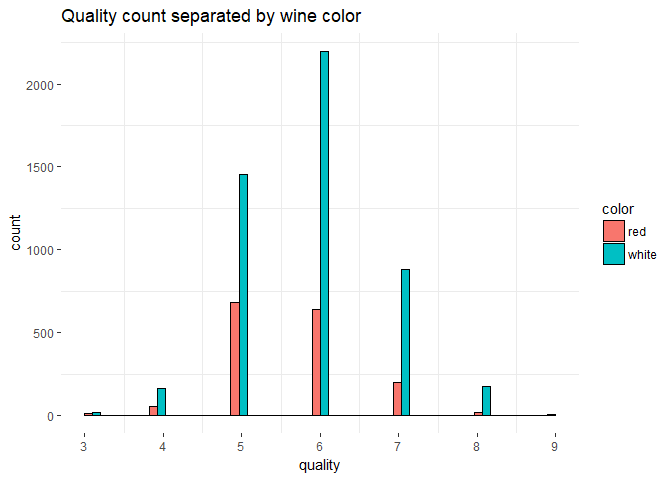

```r
ggplot(aes(x= quality, fill = color), data = df) + geom_histogram(colour= 'black', position = position_dodge()) + scale_x_continuous(breaks = seq(3,9,1)) + ggtitle('Quality count separated by wine color') + my_style
```

- This histogram represents why it was so hard to predict ‘quality’ and ‘rating’. Most of the data falls between 5,6 and 7. If there were more values for lower end and upper end of the scale, I belive it would be easier to predict ’rating. Also, there are a lot more white wines than red. Which leads to the second point, for a lot of the factors, there wasn’t enough variabilty or range to really distinguish what made sense.

#### Plot 2

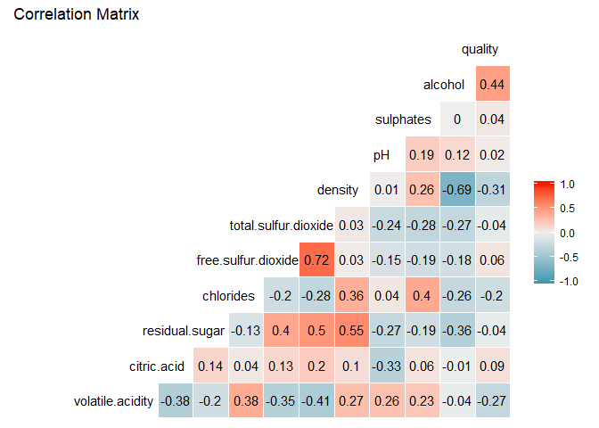

```r
ggcorr(df[,2:14], label = TRUE, label_round = 2, label_size = 4, hjust = .83, layout.exp = 3) + ggtitle('Correlation Matrix') + my_style ##remove the X or id variable
```

- This matrix shows the correlation coefficent for all the variables. It does all of the bivariate analysis in one plot. It can clearly be seen that quality is most impacted by alcohol. Also, alot of other neat realtionships can be seen just from this plot. It makes it really easy to get a nice picture of all the relationships.

#### Plot 3

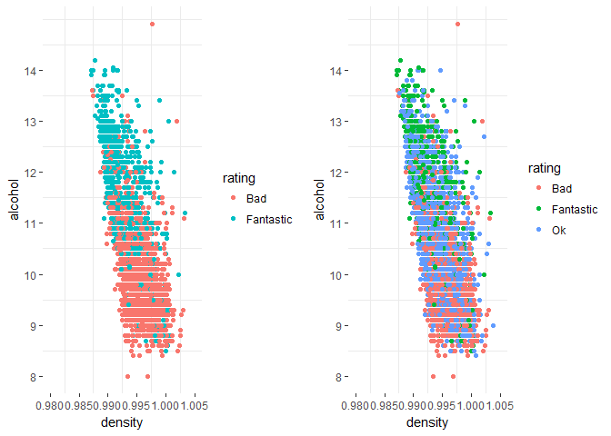

```r
library(gridExtra)
p1 = ggplot(aes(y = alcohol, x  = density, color = rating), data = subset(df, rating %in% c('Bad' , 'Fantastic'))) + geom_point() + scale_x_continuous(limits = c(.98,1.005))  + scale_y_continuous(breaks = seq(8,14,1)) + my_style ##made limit .98 to 1.005 beacuse that is where most of the data is centered

p2 = ggplot(aes(y = alcohol, x  = density, color = rating), data = df) + geom_point() + scale_x_continuous(limits = c(.98,1.005))  + scale_y_continuous(breaks = seq(8,14,1)) + my_style ##made limit .98 to 1.005 beacuse that is where most of the data is centered

grid.arrange(p1,p2, ncol = 2)
```

## Reflection

- This project was really fun. I learned alot about R and wine. There were many relationships between the variables and some were stronger than others. From the matrix and the model, the strongest relationships could be obtained. The hard part of this project was that, it was really difficult to pinpoint a concrete way to predict wine ‘rating’. Two things limit this, one I have limited knowlege of organic chemistry and two there weren’t enough diffrent variables in the dataset. In the future, the dataset could include the wine company, soil quality, or climate of the area.